# Spectral Clustering vignette

Erik Larsen

2026-03-18

# Overview

This markdown was developed to formally document an ad-hoc cluster analysis for TMEM184B immunoprecipitation tandem mass-spec experiments for **Dr. Martha Bhattacharya’s lab** at the **University of Arizona** for the endolysosomal paper under revision (2025-02-28) for the Journal of Cell Science

This vignette documents the `Spectral Clustering` of this IPMS data

## Attach Packages

```r
# data/wrangling
library(tidyverse)
library(Endo)
library(DT)

# clustering
library(pheatmap)
library(dynamicTreeCut)
  ## (kNN)
library(FNN)

# GSEA/viz
library(clusterProfiler)
library(org.Hs.eg.db)
library(ReactomePA)
library(AnnotationDbi)
library(cowplot)

# progress bar
library(progressr)

# parallelization
library(future)
library(future.apply)

# network viz
library(visNetwork)

options(stringsAsFactors = FALSE)
```

## Load the Pre-Computed Data

```r
# Load precomputed objects from preprocessing
load("../analysis/R/precompute_objects.rda")
```

## Transform the Data to Distance Matrix

```r
IPMS_dist <- 1 - stats::cor(t(IPMS_mat),
                            use = 'pairwise.complete.obs') |>
  as.matrix()
```

# Spectral Clustering

Spectral clustering *uses the same correlation-based distance representation as hierarchical clustering.*

We compute the pairwise distance matrix as **1 - Pearson correlation between proteins**, matching the above vignette, exactly.

This method was chosen because:

- the wild variation in protein abundance detected by spectrometers in these experiments
- contamination proteins often inflate abundances
- immunoprecipitation (bait) biases (differential abundance for certain proteins, depending on the antibody + target/tag)
- we want to emphasize the pattern in terms of signal, not scale

Correlation distance:

- centers and scales each protein
- removes/accounts for magnitude effects, focusing on the shape of the profile
  - is therefore robust to contaminants and bait biases

This is standard in proteomics clustering

# Construct Similarity Matrices

Build a similarity matrix from the correlation matrix of raw counts

-> will be used for clustering (closeness between data, e.g. proteins)

Two options:

1. **Gaussian similarity matrix** (using the Radial Basis Function kernel) + ideal for smooth, low-noise datasets + smooth, continuous calculations of distances without hard cutoffs
2. **k-Nearest Neighbors adjacency graph** + ideal for sparse or data with heteregeneous density; noisy data (e.g. IPMS datasets with lots of contaminants)

We will compare and select the method that yields the most stable Laplacian spectrum

## Gaussian (Radial Basis Function) Kernel Similarity Matrix

*S_ij* = exp(-(*D_ij*<sup>2)/2*sigma*</sup>2)

```r
# choose a kernel width (sigma) based on the distance distribution
sigma <- stats::median(IPMS_dist)

# compute the Gaussian (RBF) similarity matrix
sim_mat <- exp(-(IPMS_dist^2)/(2*sigma^2))
```

## kNN Adjacency

```r
# compute k-nearest neighbors from the correlation-distance matrix
kNN_idx <- FNN::get.knn(IPMS_dist, k = 10)$nn.index

# convert to binary adjacency matrix
adjacency <- matrix(0, nrow = nrow(kNN_idx), ncol = nrow(kNN_idx))

for (i in seq_len(nrow(kNN_idx))) {
  adjacency[i, kNN_idx[i, ]] <- 1
}

# make symmetrical
adjacency_sym <- (adjacency + t(adjacency)) > 0
```

# Compute the Normalized Laplacian

Compute the graph `Laplacian` of the similarity/adjacency matrix

- this is the formal encoding of the graph structure based on distribution of space (similarity distances between nodes)
- **The Laplacian**, in general, serves as a transformation of a matrix, replacing diagonal values with the row-sum of the matrix
  - the transformation replaces the off-diagonal values of the matrix with the corresponding matrix values multiplied by -1 ( (off-diagonal matrix value) * (-1) ).

  -> in other words, this captures how each protein’s similarity value differs from a weighted combination of all other proteins, where the weights are the similarity matrix entries, themselves:
  - **L = D - W**
  - where:
    - *W* is either the **Gaussian similarity matrix** (*S*, `sim_mat`) or **kNN adjacency matrix** (*A*, `adjacency_sym`)
    - *D* is the degree matrix (diagonal, i.e. row-sum of *W*, or the total connection strength of a node):
      - D[*i*,*i*] = Sum_j*W*[*i*,*j*]
      - `Gaussian`-based degrees vary smoothly; `kNN`-based degrees are roughly constant because each row has the same number of non-zero entries
- For spectral clustering, the standard approach is to use the **normalized Laplacian**, which re-scales the contribution of each row/column by its degree to account for uneven similarity magnitudes across proteins:
  - *L_norm* = *D*<sup>(-1/2)(*D*-*W*)*D*</sup>(-1/2) or *L_norm* = *I*-*D*<sup>(-1/2)*WD*</sup>(-1/2)
- **The Laplacian** is the operator whose eigenvectors reveal:
  - connected components
  - cluster structure
- **The normalized Laplacian** is essentially a function that transforms a similarity matrix (“graph” or space) in the same way as the **unnormalized Laplacian** but with an additional correction step
- The key difference is that the **normalized Laplacian** *penalizes proteins with large total similarity (large row-sums)*: the normalization re-scales each row and column by the square root of its degree
  - This makes proteins with very different total similarity strengths contribute on a comparable on the same scale, preventing high-degree proteins from dominating transformation

## Normalized Laplacian for Gaussian Similarity Matrix

Derive the normalized Laplacian from the Gaussian kernel on the correlation matrix

```r
# for the Gaussian RBF kernel similarity matrix
W <- sim_mat

# degree matrix
D <- diag(rowSums(W))

# normalized Laplacian
D_inv_sqrt <- diag(1 / sqrt(rowSums(W)))
gaussian_norm_L <- diag(nrow(W)) - D_inv_sqrt %*% W %*% D_inv_sqrt
```

## Normalized Laplacian for kNN Adjacency

Derive the normalized Laplacian from the k-Nearest Neighbors adjacency matrix

```r
## for the kNN adjacency matrix
W <- adjacency_sym

# degree matrix
D <- diag(rowSums(W))

# normalized Laplacian
D_inv_sqrt <- diag(1 / sqrt(rowSums(W)))
kNN_norm_L <- diag(nrow(W)) - D_inv_sqrt %*% W %*% D_inv_sqrt
```

# Normalized Laplacian Spectra

Conduct **eigendecomposition** and extract **eigenvectors** for each similarity matrix (graph). Compare and select for **embeddings** upon which to cluster

- **embeddings** are the numerical representations of each/every protein in lower-dimensional space
  - an **embedding** is constructed from the **eigenvectors** of the `graph Laplacian`
  - an **eigenvector** encodes how one protein relates to every other protein in the similarity graph
- this transformation places proteins in a visualizable, geometric coordinate system where proteins with similar interaction profiles are closer together and dissimilar proteins are further apart
- an embedding (represented by `k`) with multiple eigenvectors has multiple dimensions– multiple clusters– by which the proteins relate: **the number of eigenvectors = k = clusters within the graph Laplacian**

Extract the `eigenvectors` and `eigenvalues` of each similarity graph method

## Eigendecomposition of Gaussian Normalized Laplacian

```r
# compute eigendecomposition of the Gaussian RBF kernel-based normalized Laplacian
gaussian_eig <- eigen(gaussian_norm_L, symmetric = TRUE)

# extract eigenvalues and eigenvectors
gaussian_eigenvalues <- gaussian_eig$values
gaussian_eigenvectors <- gaussian_eig$vectors
```

## Eigendecomposition of kNN Normalized Laplacian

```r
# compute eigendecomposition of the kNN adjacency matrix-based normalized Laplacian
kNN_eig <- eigen(kNN_norm_L, symmetric = TRUE)

# extract eigenvalues and eigenvectors
kNN_eigenvalues <- kNN_eig$values
kNN_eigenvectors <- kNN_eig$vectors
```

# Automatic Similarity Graph Choice

Compute the **eigengap**– the largest difference between consecutive `Laplacian` **eigenvalues** in ascending order– for each graph

- The index (**eigengap**) represents the most stable number of clusters for the graph

```r
# compute eigengaps and identify the largest eigen gap for each graph
  # sort the eigenvalues
sorted_gaussian_eigenvalues <- sort(gaussian_eigenvalues)
  # find the biggest eigengap
gaussian_best_gap <- max(diff(sorted_gaussian_eigenvalues))
  # find k where this occurs
gaussian_k <- which(diff(sorted_gaussian_eigenvalues) == gaussian_best_gap)

  # sort the eigenvalues
sorted_kNN_eigenvalues <- sort(kNN_eigenvalues)
  # find the biggest eigengap
kNN_best_gap <- max(diff(sorted_kNN_eigenvalues))
  # find k where this occurs
kNN_k <- which(diff(sorted_kNN_eigenvalues) == kNN_best_gap)

# choose the graph with the larger eigengap
if (gaussian_best_gap > kNN_best_gap) {
  chosen_graph <- "gaussian"
  } else {
  chosen_graph <- "kNN"
}

# store chosen Laplacian and eigenvectors
if (chosen_graph == "gaussian") {
  L_chosen <- gaussian_norm_L
  eigvals_chosen <- gaussian_eigenvalues
  eigvecs_chosen <- gaussian_eigenvectors
  W <- sim_mat
  D <- diag(rowSums(W))
  D_inv_sqrt <- diag(1 / sqrt(rowSums(W)))
  k <- gaussian_k
} else {
  L_chosen <- kNN_norm_L
  eigvals_chosen <- kNN_eigenvalues
  eigvecs_chosen <- kNN_eigenvectors
  k <- kNN_k
}

chosen_graph
```

```
## [1] "gaussian"
```

# Spectral Embedding

## Plot Embedding Dimensions (k)

Show the `eigengap` among `eigenvalues` for each graph (computed above)

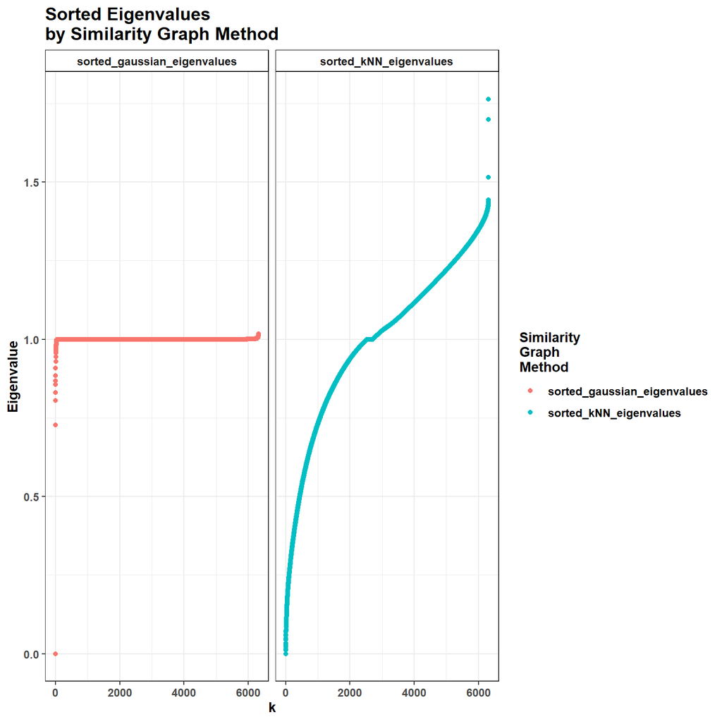

```r
sorted_kNN_eigenvalues |>
  as.data.frame() |>
  dplyr::mutate(sorted_gaussian_eigenvalues =
    sorted_gaussian_eigenvalues
  ) |>
  dplyr::mutate(k = dplyr::row_number(), .before = 1) |>
  tidyr::pivot_longer(cols = c(dplyr::contains("eig")), names_to = 'graph', values_to = 'value') |>
  dplyr::group_by(graph) |>
  ggplot2::ggplot(aes(x = k, y = value)) +
  ggplot2::geom_point(aes(group = graph, color = graph)) +
  ggplot2::labs(title = 'Sorted Eigenvalues\nby Similarity Graph Method',
                y = 'Eigenvalue',
                color = 'Similarity\nGraph\nMethod') +
  ggplot2::theme_bw()+
  ggplot2::theme(title = ggplot2::element_text(face = 'bold', size = 12),
                 axis.text = ggplot2::element_text(face = 'bold', size = 9),
                 axis.title = ggplot2::element_text(face = 'bold', size = 11),
                 legend.title = ggplot2::element_text(face = 'bold', size = 11),
                 legend.text = ggplot2::element_text(face = 'bold', size = 9),
                 strip.background = ggplot2::element_rect(color = 'black',
                                                          fill = 'white'),
                 strip.text = ggplot2::element_text(face = 'bold', size = 9)) +
  ggplot2::facet_wrap(~graph)
```

These spectra are not unexpected– `kNN` is very smooth, and the `Gaussian` is very flat, both suggesting there aren’t many clear structural boundaries in the data, which isn’t uncommon in IPMS interactomes due to the substantial overlap in protein networks (pathways, complexes, and differential functions)

## Compute the Spectral Embedding

```r
# spectral embedding
embedding <- eigvecs_chosen[, k, drop = FALSE]
```

## Results and Interpretation

We have determined `k` = **1** because the `Gaussian similarity matrix` showed the larger **eigengap** (TRUE), and this occurred at `k` = **1** in the sorted spectrum

As shown in the eigenvalue plot above, the largest slope change (largest **eigengap**) occurs between the first two eigenvalues (i.e. `k` = **1**):

- there is little structural difference within the data– very smooth for both methods, which isn’t uncommon in IPMS interactomes (see section above for rationale)

This indicates that the `Laplacian spectrum` contains **no evidence of more than one meaningful cluster**, and under the eigengap rule, this yields a *1-dimensional embedding*

# k-means Clustering

Conduct `k-means clustering` on the `eigenvectors`/`embedding`

## Extract Clusters

(1 for all proteins)

```r
set.seed(4)
labels <- stats::kmeans(embedding, centers = k)$cluster

clusters_df <- labels |>
  as.data.frame() |>
  dplyr::mutate(Protein = colnames(IPMS_dist), .before = 1) |>
  dplyr::rename(cluster = 2)

head(clusters_df)
```

```
##   Protein cluster
## 1   A2ML1       1
## 2    AAAS       1
## 3    AACS       1
## 4    AAK1       1
## 5   AAMDC       1
## 6    AAMP       1
```

# Cluster Descriptions

## Join Clusters to hSAINT

Include score summaries (mean and median `posterior probability scores`, `ranks`, and literature or CRAPome `contamination rates`)

```r
spectral_cluster_scores <- labels |>
  as.data.frame() |>
  dplyr::mutate(Protein = colnames(IPMS_dist), .before = 1) |>
  dplyr::select(Protein) |>
  dplyr::mutate(cluster = labels) |>
  dplyr::inner_join(
    hSAINT
  ) |>
  dplyr::arrange(desc(score)) |>
  dplyr::group_by(cluster) |>
  dplyr::summarize(mean_score = mean(score),
                   median_score = stats::median(score),
                   score_mass = sum(score),
                   n = dplyr::n(),
                   lit_flag_perc = (sum(lit_flag)/n)*100,
                   CRAPome_flag_perc = (sum(CRAPome_flag)/n)*100) |>
  dplyr::arrange(desc(mean_score)) |>
  dplyr::mutate(mean_rank = dplyr::row_number()) |>
  dplyr::arrange(desc(median_score)) |>
  dplyr::mutate(median_rank = dplyr::row_number()) |>
  dplyr::arrange(desc(score_mass)) |>
  dplyr::mutate(total_rank = dplyr::row_number()) |>
  dplyr::arrange(mean_rank)

spectral_cluster_scores
```

```
## # A tibble: 1 × 10
##   cluster mean_score median_score score_mass     n lit_flag_perc
##     <int>      <dbl>        <dbl>      <dbl> <int>         <dbl>
## 1       1      0.445        0.230      2804.  6308          6.04
## # ℹ 4 more variables: CRAPome_flag_perc <dbl>, mean_rank <int>,
## #   median_rank <int>, total_rank <int>
```

Join the cluster scores to the cluster (per protein) dataframe and the `hSAINT` results for classification (for posterity)

```r
spectral_protein_cluster_df <- clusters_df |>
  dplyr::inner_join(
    hSAINT
  ) |>
  dplyr::full_join(
    spectral_cluster_scores
  ) |>
  dplyr::arrange(desc(score)) |>
  dplyr::mutate(
    SAINT_classification = dplyr::case_when(

      mean_rank <= 5 ~ 'High SAINT',
      mean_rank > 5 ~ 'Low SAINT'
      ),

    contams_classification = dplyr::case_when(

      lit_flag_perc > 5 ~'High Contaminants',
      TRUE ~ 'Low Contaminants')) |>

  dplyr::mutate(classification = paste0(SAINT_classification,
                                        ", ",
                                        contams_classification)) |>
  dplyr::select(-SAINT_classification,
                -contams_classification) |>
  dplyr::relocate(classification, .after = cluster)

head(spectral_protein_cluster_df)
```

```
##   Protein cluster                classification score lit_flag CRAPome_flag
## 1   ABCD3       1 High SAINT, High Contaminants     1        0            1
## 2   ABCE1       1 High SAINT, High Contaminants     1        0            0
## 3   ABCF2       1 High SAINT, High Contaminants     1        0            0
## 4   ACACA       1 High SAINT, High Contaminants     1        0            0
## 5    ACLY       1 High SAINT, High Contaminants     1        0            0
## 6   ACTC1       1 High SAINT, High Contaminants     1        0            0
##                      stat_class mean_score median_score score_mass    n
## 1 High SAINT, Low Contamination  0.4445926    0.2301594    2804.49 6308
## 2 High SAINT, Low Contamination  0.4445926    0.2301594    2804.49 6308
## 3 High SAINT, Low Contamination  0.4445926    0.2301594    2804.49 6308
## 4 High SAINT, Low Contamination  0.4445926    0.2301594    2804.49 6308
## 5 High SAINT, Low Contamination  0.4445926    0.2301594    2804.49 6308
## 6 High SAINT, Low Contamination  0.4445926    0.2301594    2804.49 6308
##   lit_flag_perc CRAPome_flag_perc mean_rank median_rank total_rank
## 1      6.039949          1.949905         1           1          1
## 2      6.039949          1.949905         1           1          1
## 3      6.039949          1.949905         1           1          1
## 4      6.039949          1.949905         1           1          1
## 5      6.039949          1.949905         1           1          1
## 6      6.039949          1.949905         1           1          1
```

## Cluster GO GSEA

```r
EntrezIDs <- AnnotationDbi::select(
  org.Hs.eg.db,
  keys = colnames(IPMS_dist),
  columns = 'ENTREZID',
  keytype = 'SYMBOL'
) |>
  dplyr::filter(!is.na(2))

EntrezMap <- stats::setNames(EntrezIDs$ENTREZID, EntrezIDs$SYMBOL)
```

Create enrichment functions

```r
background_genes <- EntrezIDs |> # use the EntrezIDs mapped from the modules_df
  dplyr::pull(ENTREZID)

get_GO <- function(genes, ontology, background_genes) {
  clusterProfiler::enrichGO(
    gene = genes,
    universe = background_genes,
    OrgDb = org.Hs.eg.db,
    keyType = 'ENTREZID',
    ont = ontology,
    pAdjustMethod = 'BH',
    qvalueCutoff = 0.05,
    readable = T
  )
}

get_kegg <- function(genes, EntrezMap) {
  entrez <- EntrezMap[genes]
  entrez <- entrez[!is.na(entrez)]
  if (length(entrez)==0) {
    return(NULL)
  }
  clusterProfiler::enrichKEGG(
    gene = entrez,
    organism = 'hsa',
    pAdjustMethod = 'BH',
    qvalueCutoff = 0.05
  )
}

get_reactome <- function(genes, EntrezMap) {
  entrez <- EntrezMap[genes]
  entrez <- entrez[!is.na(entrez)]
  if (length(entrez)==0) {
    return(NULL)
  }
  ReactomePA::enrichPathway(
    gene = entrez,
    organism = 'human',
    pAdjustMethod = 'BH',
    qvalueCutoff = 0.05,
    readable = T
  )
}
```

Run the functions on the dataset in parallel (multiple CPUs)

```r
future::plan(future::multisession, workers = 6)
progressr::handlers(progressr::handler_txtprogressbar())

cluster_ids <- unique(labels)

progressr::with_progress({
  p <- progressr::progressor(steps = length(cluster_ids))

  enrichment_results <- future.apply::future_lapply(
    cluster_ids,
    function(mod) {

      # tick the progress bar
      p(sprintf("cluster %s", mod))

      genes <- labels |>
        as.data.frame() |>
        dplyr::mutate(Protein = colnames(IPMS_dist), .before = 1) |>
        dplyr::rename(cluster = labels) |>
        dplyr::filter(cluster == mod) |>
        dplyr::inner_join(EntrezIDs |> dplyr::rename(Protein = 1)) |>
        dplyr::distinct(ENTREZID) |>
        dplyr::pull(ENTREZID)

      list(
        cluster = mod,
        go_bp  = get_GO(genes, ontology = "BP", background_genes = background_genes),
        go_cc  = get_GO(genes, ontology = "CC", background_genes = background_genes),
        go_mf  = get_GO(genes, ontology = "MF", background_genes = background_genes)
        # add KEGG/Reactome later
      )
    }
  )
})

names(enrichment_results) <- cluster_ids
rm(p)
```

Gather enrichment results

```r
spectral_enrichment_results_df <- enrichment_results |>
  purrr::pluck(1) |>
  purrr::list_merge() %>%
  purrr::map_df(., .f = as.data.frame) |>
  dplyr::rename(cluster = 1, GO_Term = Description, GO_ID = ID)

spectral_enrichment_results_df
```

[output not shown]

**No GO Terms were enriched** in the only cluster of the spectral clustering method. As in Endo/Rpkg/vignette/HierarchicalClustering.Rmd, we would run GO enrichment on the clusters that did not return enrichment results, using only each cluster’s proteins as the background for enrichment

- In this case, that remains the same background protein list, since it is the only cluster in the data
- **This yields the same result**

## Cluster Barplot

For posterity, since there are no enriched GO Terms from the only cluster in the data

[figure not shown]

```r
spectral_enrichment_results_df |>
  dplyr::full_join(spectral_cluster_scores) |>
  dplyr::filter(!is.na(GO_Term)) |>
  dplyr::mutate(
    is_enriched = 'Not Enriched'
    ) |>
  dplyr::group_by(cluster) |>
  dplyr::arrange(p.adjust) |>
  ggplot2::ggplot(
    ggplot2::aes(
      x = -log10(p.adjust),
      y = forcats::fct_rev(forcats::fct_infreq(GO_Term, mean_score)),
      size = FoldEnrichment,
      alpha = mean_score,
      shape = is_enriched,
    )
  ) +
  ggplot2::geom_vline(xintercept = -log10(0.05),
                      linetype = 'dashed',
                      color = 'firebrick',
                      size = 1,
                      alpha = 0.5) +
  ggplot2::geom_point() +
  ggplot2::labs(title = 'GO Enrichment Across Clusters\nDerived from Eigendecomposition and k-means (Spectral Clustering)\nin TMEM184B IPMS',
                x = '-log10(Adj.P-val)',
                y = 'GO Term',
                alpha = 'Cluster\nMean\nHierarchical\nSAINT\nScore',
                size = 'FoldEnrichment',
                shape = 'IsEnrichedCluster') +
  ggplot2::theme_bw() +
  ggplot2::theme(title = ggplot2::element_text(face = 'bold', size = 12),
                 axis.text = ggplot2::element_text(face = 'bold', size = 10),
                 strip.text = ggplot2::element_text(face = 'bold', size = 7),
                 strip.background = ggplot2::element_rect(color = 'black',
                                                          fill = 'white')) +
  ggplot2::guides(#shape = ggplot2::guide_legend(override.aes = list(size = 4, shape = c(19, 17))),
                  color = ggplot2::guide_legend(override.aes = list(size = 4,
                                                                    shape = 19,
                                                                    color = c('navy',
                                                                              'darkgoldenrod3',
                                                                              'firebrick'))),
                  alpha = ggplot2::guide_legend(override.aes = list(size = 5,
                                                                    shape = 19)),
                  size = ggplot2::guide_legend(override.aes = list(shape = 19))
                  # size = 'none'
                  ) +
  ggplot2::scale_fill_manual(values = c('navy',
                                        'darkgoldenrod3',
                                        'firebrick'))
```

## Downsample Heatmap of Similarity Matrix

Subset the heatmap of the similarity matrix (for rendering/interpretability)

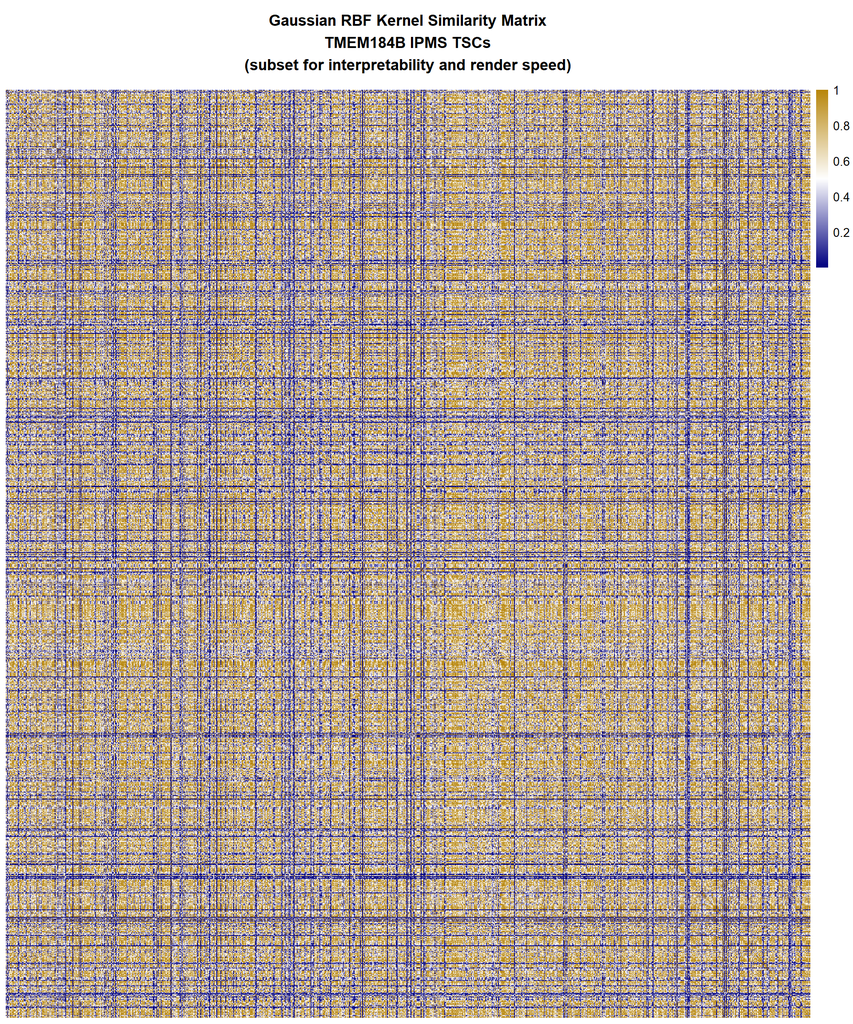

```r
idx <- sample(seq_len(nrow(sim_mat)), 1000)
pheatmap::pheatmap(
  sim_mat[idx, idx],
  color = grDevices::colorRampPalette(c('navy',
                                        'white',
                                        'darkgoldenrod'))((200)),
  cluster_rows = F,
  cluster_cols = F,
  show_rownames = F,
  show_colnames = F,
  main = 'Gaussian RBF Kernel Similarity Matrix\nTMEM184B IPMS TSCs\n(subset for interpretability and render speed)'
)
```

The diagonal is not visually distinct because many proteins have near-identical similarity profiles, producing relatively large high-similarity (gold) regions.

This pattern is characteristic of a 1-dimensional spectral structure with no modularity and is not inconsistent with interactome profiles (see Compute the Spectral Embedding subsection)

## PCA on Embedding

Conduct `PCA` on the spectral embedding

- since `k` = **1**, *there will only be one component* (**PC1**)
- we, therefore, plot the distribution of this component across the protein index of the embedding

```r
pca_embedding <- stats::prcomp(embedding, center = TRUE, scale = FALSE)

pc1 <- pca_embedding$x[, 1]

df_pc1 <- tibble::tibble(
  index = seq_along(pc1),
  PC1 = pc1
)
```

```r
pca_embedding$x <- pca_embedding$x[1:5, 1, drop = FALSE]

head(pca_embedding)
```

```
## $sdev
## [1] 0.01258471
##
## $rotation
##      PC1
## [1,]   1
##
## $center
## [1] 5.780497e-05
##
## $scale
## [1] FALSE
##
## $x
##               PC1
## [1,]  0.002021774
## [2,] -0.004472397
## [3,]  0.003107855
## [4,]  0.015277353
## [5,] -0.012480138
```

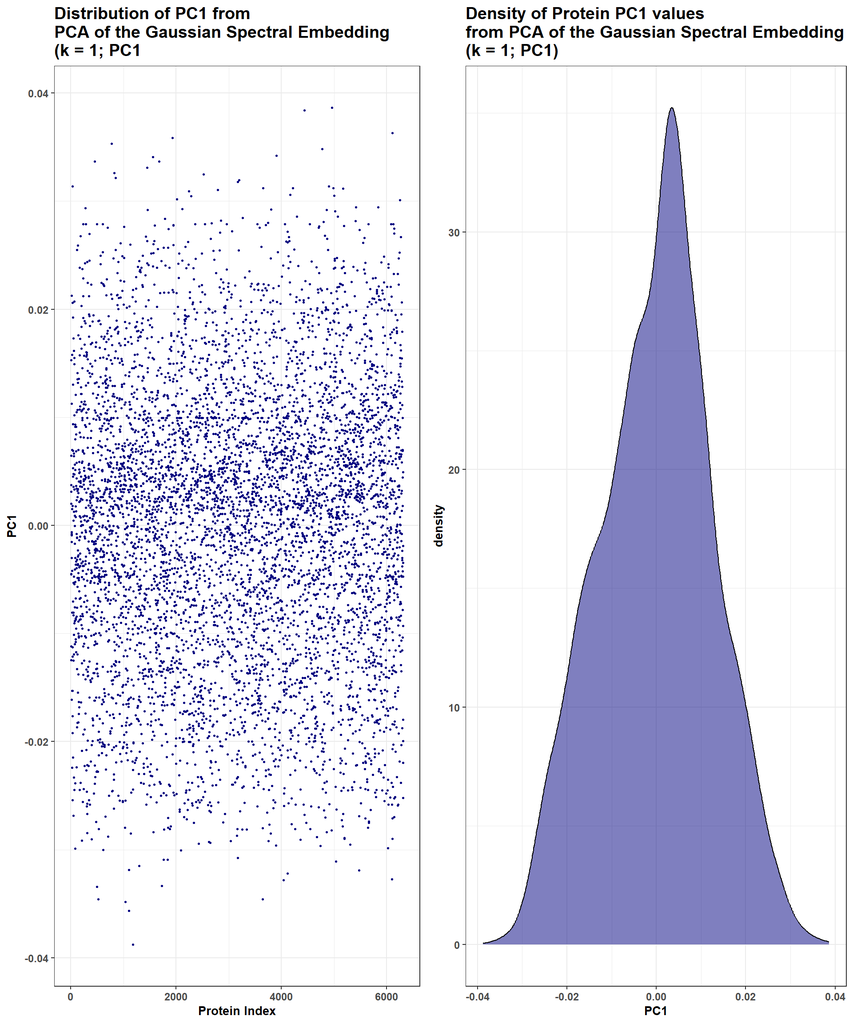

```r
cowplot::plot_grid(
  df_pc1 |>
  ggplot2::ggplot(ggplot2::aes(x = index, y = PC1)) +
  ggplot2::geom_point(size = 0.6, color = 'navy') +
  ggplot2::labs(title = 'Distribution of PC1 from\nPCA of the Gaussian Spectral Embedding\n(k = 1; PC1',
                x = 'Protein Index',
                y = 'PC1') +
  ggplot2::theme_bw() +
  ggplot2::theme(title = ggplot2::element_text(face = 'bold', size = 12),
                 axis.title = ggplot2::element_text(face = 'bold', size = 10),
                 axis.text = ggplot2::element_text(face = 'bold', size = 9)),

  df_pc1 |>
  ggplot2::ggplot(ggplot2::aes(x = PC1)) +
  ggplot2::geom_density(fill = 'navy', alpha = 0.5)+
  ggplot2::labs(title = 'Density of Protein PC1 values\nfrom PCA of the Gaussian Spectral Embedding\n(k = 1; PC1)',
                x = 'PC1',
                y = 'density') +
  ggplot2::theme_bw() +
  ggplot2::theme(title = ggplot2::element_text(face = 'bold', size = 12),
                 axis.title = ggplot2::element_text(face = 'bold', size = 10),
                 axis.text = ggplot2::element_text(face = 'bold', size = 9))
  ,
  ncol = 2,
  align = 'h'
)
```

## Construct the Cluster GO (similarity) Network

For posterity, *since there are no enriched terms*, **no GO network can be constructed**

```r
spectral_enrichment_results_df |>
  dplyr::full_join(spectral_cluster_scores) |>
  dplyr::mutate(node_to = GO_Term,
                node_from = cluster,
                weight = -log10(p.adjust)) |>
  dplyr::filter(weight > -log10(0.05))
```

```
##  [1] cluster           GO_ID             GO_Term           GeneRatio
##  [5] BgRatio           RichFactor        FoldEnrichment    zScore
##  [9] pvalue            p.adjust          qvalue            geneID
## [13] Count             mean_score        median_score      score_mass
## [17] n                 lit_flag_perc     CRAPome_flag_perc mean_rank
## [21] median_rank       total_rank        node_to           node_from
## [25] weight
## <0 rows> (or 0-length row.names)
```

# Results Tables

To conclude, in this dataset, spectral clustering on the `Gaussian kernel graph` produced *a single coherent cluster*. The **eigengap** analysis supported this outcome and the 1-dimensional spectral embedding showed **no evidence of separable substructure**

Because all proteins fell into this one cluster, GO enrichment analysis returned **no significant terms**– there is no contrast set against which to detect over-representation. Some datasets do not contain multiple functional clusters at the resolution provided by their similarity structure

The spectral workflow still provides a reproducible, graph-based view of the data, even when the optimal partition is a single group